# Analysis

[Guillermo Montero-Melis](https://www.mpi.nl/people/montero-melis-guillermo)

2022-02-06

# 1 Introduction

This script fully documents the results and control analyses reported in

Montero-Melis et al., 2021. No evidence for embodiment: The motor system is not needed to keep action words in working memory. Submitted to *Cortex* (Stage 2 Registered Report).

The script follows our pre-registered analyses as specified in the Stage 1 submission of our Registered Report, which can be found [here](https://osf.io/26fbh/). The analyses are ordered in the same way as in the article.

# 2 Session set up

Load libraries:

```r
library("knitr")
library("tidyverse")
library("brms")
library("egg")  # theme_article()
library("sjPlot")
library("lme4")
theme_set(theme_article(base_size = 18))  # ggplot theme
knitr::opts_chunk$set(fig.height=4)
```

Source file where functions are defined:

```r
source("myfunctions/analysis_fncs.R")
```

Load experiment data:

```r
# load participant metadata
ppts <- read_csv("../data/ppt_info.csv")
# First 60 participants
d60_w_control <- read_csv("../data/data60.csv") %>%
  rename(subject = ID_unique)
d60_w_control <- d60_w_control %>%
  group_by(subject, trial_exp) %>%
  mutate(preced_error = preced_error(error))
# data frame with only the critical conditions
d60 <- d60_w_control %>% filter(block_type != "CONTROL")
kable(head(d60))
```

| subject | ID | block | block_type | trial_block | word_type | trial_exp | word_pos | verb | transcription | error | preced_error |
| --- | --- | --- | --- | --- | --- | --- | --- | --- | --- | --- | --- |
| 1_2020_Oct_30_1334 | 1 | 2 | ARM | 1 | leg | 27 | 1 | vingla | vingla rangla vinkla vakna | 0 | 0 |
| 1_2020_Oct_30_1334 | 1 | 2 | ARM | 1 | leg | 27 | 2 | knäa | vingla rangla vinkla vakna | 1 | 0 |
| 1_2020_Oct_30_1334 | 1 | 2 | ARM | 1 | leg | 27 | 3 | ragla | vingla rangla vinkla vakna | 1 | 1 |
| 1_2020_Oct_30_1334 | 1 | 2 | ARM | 1 | leg | 27 | 4 | cykla | vingla rangla vinkla vakna | 1 | 1 |
| 1_2020_Oct_30_1334 | 1 | 2 | ARM | 2 | leg | 28 | 1 | vandra | NA | 1 | 0 |
| 1_2020_Oct_30_1334 | 1 | 2 | ARM | 2 | leg | 28 | 2 | flanera | NA | 1 | 1 |

```r
# all 77 valid participants
d77_w_control <- read_csv("../data/data_all.csv") %>%
  rename(subject = ID_unique)
d77_w_control <- d77_w_control %>%
  group_by(subject, trial_exp) %>%
  mutate(preced_error = preced_error(error))
# data frame with only the critical conditions
d77 <- d77_w_control %>% filter(block_type != "CONTROL")
```

Load the model fitted to the original data (see re-analysis - Appendix B) and extract the posterior for the critical interaction effect for later use as the prior for the replication Bayes factor:

```r
# Load brms model fitted to original data. It's a list with three objects: the
# full model is the first element of that list:
bfm_orig <- readRDS("mymodels/sp13_bfm_max.rds")[[1]]
# If you get an error, it probably means you have to download the actual RDS
# file. Go to
# https://github.com/montero-melis/2021_cortex_RR_montero-melis-et-al/blob/main/analysis/mymodels/sp13_bfm_max.rds
# download the file and store it in the right path ("analysis/mymodels/sp13_bfm_max.rds")

# Extract posterior estimates for the critical interaction effect from the brms
# model (pull converts it to a numerical vector):
beta_posterior <- pull(posterior_samples(bfm_orig, "b_mv_wt"))
sp13_posterior <- c(mean(beta_posterior), sd(beta_posterior))
names(sp13_posterior) <- c("M", "SD")
sp13_posterior
```

```
##          M         SD
## 0.14586369 0.04829117
```

```r
# here and below I remove unneeded objects from the workspace to avoid memory
# management issues ("cannot allocate vector of size..."); see
# https://stackoverflow.com/questions/5171593/r-memory-management-cannot-allocate-vector-of-size-n-mb
rm(bfm_orig)  # memory management
```

# 3 Participant descriptives

## 3.1 Participant age

```r
summary(ppts$age)
```

```
##    Min. 1st Qu.  Median    Mean 3rd Qu.    Max.
##   18.00   22.00   25.00   25.44   28.00   40.00
```

```r
sd(ppts$age)
```

```
## [1] 4.618309
```

## 3.2 Sex/gender

```r
table(ppts$sex)
```

```
##
##                                  annat
##                                      1
## blank (deltagaren glömde nog - kvinna)
##                                      1
##    blank (deltagaren glömde nog - man)
##                                      1
##                                 kvinna
##                                     46
##                                    man
##                                     27
##                              man/annat
##                                      1
```

## 3.3 Paradiddle speed

```r
se <- function(x) { sd(x) / sqrt(length(x)) }
# hands
mean(ppts$BPM_hands)
```

```
## [1] 209.8701
```

```r
sd(ppts$BPM_hands)
```

```
## [1] 60.44775
```

```r
se(ppts$BPM_hands)
```

```
## [1] 6.88866
```

```r
# feet
mean(ppts$BPM_feet)
```

```
## [1] 189.4805
```

```r
sd(ppts$BPM_feet)
```

```
## [1] 43.3133
```

```r
se(ppts$BPM_feet)
```

```
## [1] 4.936009
```

## 3.4 Handedness

```r
summary(ppts$hand_quot)
```

```
##    Min. 1st Qu.  Median    Mean 3rd Qu.    Max.
##   15.00   45.00   50.00   55.71   65.00  100.00
```

```r
sd(ppts$hand_quot)
```

```
## [1] 16.69609
```

# 4 Main results with $N=77$ (all participants)

We continued collecting participants while processing the data for our first pre-registered analysis for $N=60$. We stopped data collection when the analysis with $N=60$ showed reliable evidence in favor of the null hypothesis (based on our pre-defined Bayes factor, see manuscript and below). By then we had collected 77 participants in total. **Here we report the results of the analyses with all 77 participants**, which constitute our main results.

## 4.1 Visualization of raw data

Critical conditions:

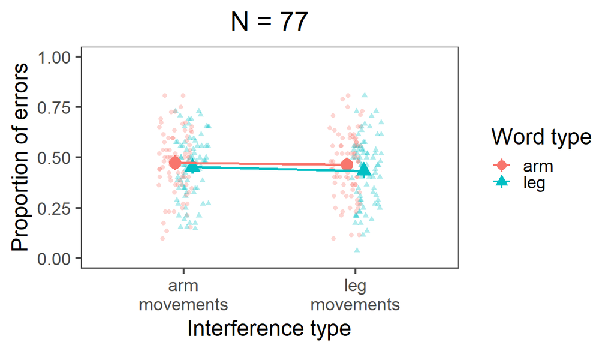

```r
plot_raw_data(d77_w_control, "N = 77")
```

```r
my_ggsave("SP13_replication_raw_d77", 6, 4)
```

Including the control condition for comparison:

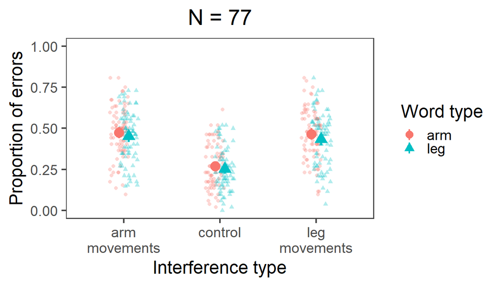

```r
plot_raw_data(d77_w_control, "N = 77", excl_CONTROL = FALSE)
```

```r
my_ggsave("SP13_replication_raw_control_d77", 6, 4)
```

## 4.2 Analysis with pre-registered analysis pipeline

### 4.2.1 Main analysis - with weakly informative priors

#### 4.2.1.1 Model fitting

Fit the models (or load if already fitted). Note that the function used for the analysis is defined in a separate script sourced at the beginning of this report (see `analysis/myfunctions/analysis_fncs.R` in this repository).

```r
ptm <- proc.time()
# analysis_pipe() tries to load the models from disk and fits them if that fails
results_brms_d77 <- analysis_pipe(d77)
```

```
## The list of models mymodels/results_brms_d77.rds exists on disk, so we load it...
```

```r
# Stop the clock
time_models <- proc.time() - ptm
time_models
```

```
##    user  system elapsed
##   23.78    2.22   26.45
```

#### 4.2.1.2 Model visualization

Visualization of the model estimates:

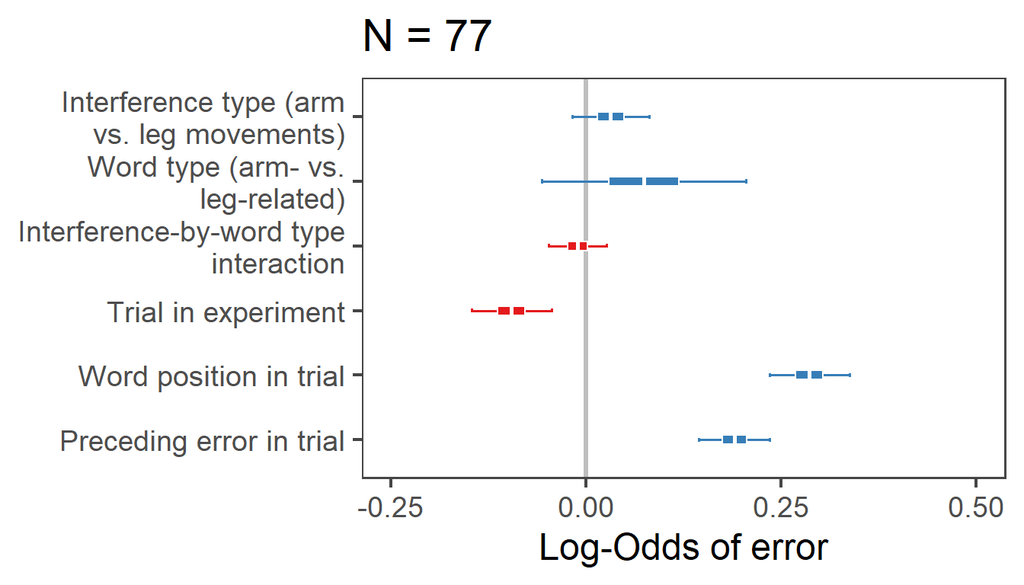

```r
plot_mymodel(results_brms_d77[[1]], "N = 77")
```

```
## Note: uncertainty of error terms are not taken into account. You may want to use `rstantools::posterior_predict()`.
```

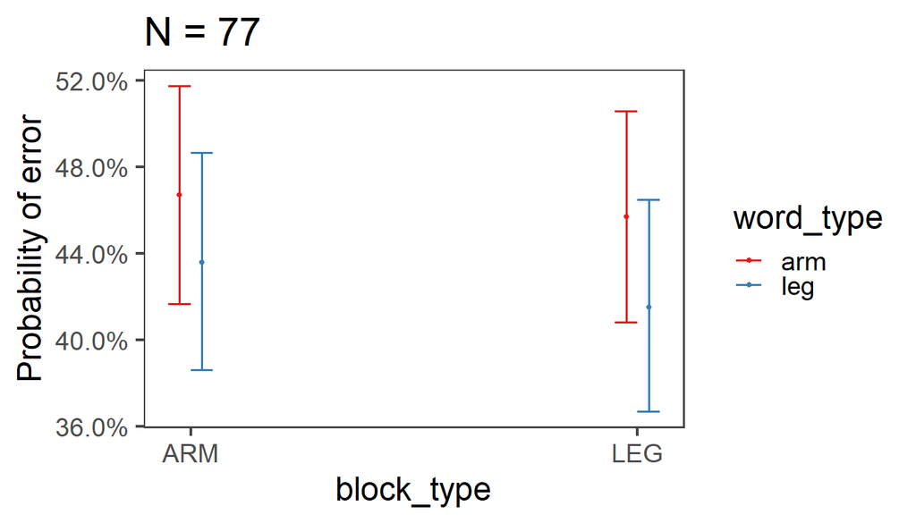

```r
my_ggsave("SP13_replication_model_estim_d77", 6, 6)
plot_interaction(results_brms_d77[[1]], "N = 77")
```

```r
my_ggsave("SP13_replication_model_interact_d77", 6, 6)
```

#### 4.2.1.3 Model summaries

Model summaries for each of the two models, the full and the null version:

```r
summary(results_brms_d77[[1]])  # full
```

```
##  Family: bernoulli
##   Links: mu = logit
## Formula: error ~ block_type + word_type + trial_exp_z + word_pos_z + preced_error_z + (1 + block_type * word_type | subject) + (1 + block_type | verb) + block_type:word_type
##    Data: df (Number of observations: 15752)
## Samples: 4 chains, each with iter = 20000; warmup = 2000; thin = 1;
##          total post-warmup samples = 72000
##
## Group-Level Effects:
## ~subject (Number of levels: 77)
##                                                                    Estimate
## sd(Intercept)                                                          0.68
## sd(block_typearm_vs_leg)                                               0.15
## sd(word_typearm_vs_leg)                                                0.06
## sd(block_typearm_vs_leg:word_typearm_vs_leg)                           0.02
## cor(Intercept,block_typearm_vs_leg)                                   -0.04
## cor(Intercept,word_typearm_vs_leg)                                    -0.12
## cor(block_typearm_vs_leg,word_typearm_vs_leg)                          0.15
## cor(Intercept,block_typearm_vs_leg:word_typearm_vs_leg)                0.11
## cor(block_typearm_vs_leg,block_typearm_vs_leg:word_typearm_vs_leg)    -0.05
## cor(word_typearm_vs_leg,block_typearm_vs_leg:word_typearm_vs_leg)     -0.02
##                                                                    Est.Error
## sd(Intercept)                                                           0.06
## sd(block_typearm_vs_leg)                                                0.03
## sd(word_typearm_vs_leg)                                                 0.03
## sd(block_typearm_vs_leg:word_typearm_vs_leg)                            0.02
## cor(Intercept,block_typearm_vs_leg)                                     0.18
## cor(Intercept,word_typearm_vs_leg)                                      0.33
## cor(block_typearm_vs_leg,word_typearm_vs_leg)                           0.37
## cor(Intercept,block_typearm_vs_leg:word_typearm_vs_leg)                 0.43
## cor(block_typearm_vs_leg,block_typearm_vs_leg:word_typearm_vs_leg)      0.44
## cor(word_typearm_vs_leg,block_typearm_vs_leg:word_typearm_vs_leg)       0.44
##                                                                    l-95% CI
## sd(Intercept)                                                          0.57
## sd(block_typearm_vs_leg)                                               0.09
## sd(word_typearm_vs_leg)                                                0.00
## sd(block_typearm_vs_leg:word_typearm_vs_leg)                           0.00
## cor(Intercept,block_typearm_vs_leg)                                   -0.38
## cor(Intercept,word_typearm_vs_leg)                                    -0.74
## cor(block_typearm_vs_leg,word_typearm_vs_leg)                         -0.64
## cor(Intercept,block_typearm_vs_leg:word_typearm_vs_leg)               -0.75
```

[output cut: 63 more lines]

```
## word_pos_z                                   0.29      0.03     0.24
## preced_error_z                               0.19      0.02     0.14
## block_typearm_vs_leg:word_typearm_vs_leg    -0.01      0.02    -0.05
##                                          u-95% CI Rhat Bulk_ESS Tail_ESS
## Intercept                                   -0.03 1.00     8684    16965
## block_typearm_vs_leg                         0.08 1.00    72400    61938
## word_typearm_vs_leg                          0.21 1.00    11336    22291
## trial_exp_z                                 -0.04 1.00    65015    58868
## word_pos_z                                   0.34 1.00    85777    61093
## preced_error_z                               0.24 1.00    97621    60606
## block_typearm_vs_leg:word_typearm_vs_leg     0.03 1.00   142995    52386
##
## Samples were drawn using sampling(NUTS). For each parameter, Eff.Sample
## is a crude measure of effective sample size, and Rhat is the potential
## scale reduction factor on split chains (at convergence, Rhat = 1).
```

```r
summary(results_brms_d77[[2]])  # null
```

```
##  Family: bernoulli
##   Links: mu = logit
## Formula: error ~ block_type + word_type + trial_exp_z + word_pos_z + preced_error_z + (1 + block_type * word_type | subject) + (1 + block_type | verb)
##    Data: df (Number of observations: 15752)
## Samples: 4 chains, each with iter = 20000; warmup = 2000; thin = 1;
##          total post-warmup samples = 72000
##
## Group-Level Effects:
## ~subject (Number of levels: 77)
##                                                                    Estimate
## sd(Intercept)                                                          0.68
## sd(block_typearm_vs_leg)                                               0.15
## sd(word_typearm_vs_leg)                                                0.06
## sd(block_typearm_vs_leg:word_typearm_vs_leg)                           0.02
## cor(Intercept,block_typearm_vs_leg)                                   -0.03
## cor(Intercept,word_typearm_vs_leg)                                    -0.12
## cor(block_typearm_vs_leg,word_typearm_vs_leg)                          0.15
## cor(Intercept,block_typearm_vs_leg:word_typearm_vs_leg)                0.10
## cor(block_typearm_vs_leg,block_typearm_vs_leg:word_typearm_vs_leg)    -0.05
## cor(word_typearm_vs_leg,block_typearm_vs_leg:word_typearm_vs_leg)     -0.01
##                                                                    Est.Error
## sd(Intercept)                                                           0.06
## sd(block_typearm_vs_leg)                                                0.03
## sd(word_typearm_vs_leg)                                                 0.03
## sd(block_typearm_vs_leg:word_typearm_vs_leg)                            0.02
## cor(Intercept,block_typearm_vs_leg)                                     0.18
## cor(Intercept,word_typearm_vs_leg)                                      0.33
## cor(block_typearm_vs_leg,word_typearm_vs_leg)                           0.37
## cor(Intercept,block_typearm_vs_leg:word_typearm_vs_leg)                 0.43
## cor(block_typearm_vs_leg,block_typearm_vs_leg:word_typearm_vs_leg)      0.44
## cor(word_typearm_vs_leg,block_typearm_vs_leg:word_typearm_vs_leg)       0.45
##                                                                    l-95% CI
## sd(Intercept)                                                          0.57
## sd(block_typearm_vs_leg)                                               0.09
## sd(word_typearm_vs_leg)                                                0.00
## sd(block_typearm_vs_leg:word_typearm_vs_leg)                           0.00
## cor(Intercept,block_typearm_vs_leg)                                   -0.38
## cor(Intercept,word_typearm_vs_leg)                                    -0.73
## cor(block_typearm_vs_leg,word_typearm_vs_leg)                         -0.64
## cor(Intercept,block_typearm_vs_leg:word_typearm_vs_leg)               -0.75
```

[output cut: 61 more lines]

```
## word_typearm_vs_leg      0.08      0.07    -0.06     0.21 1.00    11195
## trial_exp_z             -0.10      0.03    -0.15    -0.04 1.00    64661
## word_pos_z               0.29      0.03     0.23     0.34 1.00    83281
## preced_error_z           0.19      0.02     0.14     0.24 1.00    98606
##                      Tail_ESS
## Intercept               17360
## block_typearm_vs_leg    57825
## word_typearm_vs_leg     22220
## trial_exp_z             59632
## word_pos_z              60264
## preced_error_z          56598
##
## Samples were drawn using sampling(NUTS). For each parameter, Eff.Sample
## is a crude measure of effective sample size, and Rhat is the potential
## scale reduction factor on split chains (at convergence, Rhat = 1).
```

#### 4.2.1.4 Bayes factor

Compute Bayes Factor:

```r
ptm <- proc.time()
results_brms_d77_BF <- my_BF_wrapper(results_brms_d77)
```

```
## [1] "mymodels/results_brms_d77_BF.rds"
## The BF analysis mymodels/results_brms_d77_BF.rds exists on disk, so we load it...
```

```r
time_bridge <- proc.time() - ptm
time_bridge
```

```
##    user  system elapsed
##    0.01    0.00    0.02
```

**Bayes factor:**

```r
results_brms_d77_BF
```

```
## Estimated Bayes factor in favor of bridge1 over bridge2: 0.01099
```

```r
1 / results_brms_d77_BF$bf
```

```
## [1] 90.98425
```

```r
# memory management
rm(results_brms_d77, results_brms_d77_BF)
```

### 4.2.2 Secondary analysis - replication BF using original results from SP13 as priors

#### 4.2.2.1 Model fitting

Fit the models:

```r
ptm <- proc.time()
results_brms_d77_repBF <- analysis_pipe(d77, repBF = TRUE, repBF_post = sp13_posterior)
```

```
## The list of models mymodels/results_brms_d77_repBF.rds exists on disk, so we load it...
```

```r
# Stop the clock
time_models <- proc.time() - ptm
time_models
```

```
##    user  system elapsed
##   21.69    1.47   23.99
```

#### 4.2.2.2 Model summaries

Model summaries:

```r
summary(results_brms_d77_repBF[[1]])  # full
```

```
##  Family: bernoulli
##   Links: mu = logit
## Formula: error ~ block_type + word_type + trial_exp_z + word_pos_z + preced_error_z + (1 + block_type * word_type | subject) + (1 + block_type | verb) + block_type:word_type
##    Data: df (Number of observations: 15752)
## Samples: 4 chains, each with iter = 20000; warmup = 2000; thin = 1;
##          total post-warmup samples = 72000
##
## Group-Level Effects:
## ~subject (Number of levels: 77)
##                                                                    Estimate
## sd(Intercept)                                                          0.68
## sd(block_typearm_vs_leg)                                               0.15
## sd(word_typearm_vs_leg)                                                0.06
## sd(block_typearm_vs_leg:word_typearm_vs_leg)                           0.02
## cor(Intercept,block_typearm_vs_leg)                                   -0.03
## cor(Intercept,word_typearm_vs_leg)                                    -0.11
## cor(block_typearm_vs_leg,word_typearm_vs_leg)                          0.15
## cor(Intercept,block_typearm_vs_leg:word_typearm_vs_leg)                0.10
## cor(block_typearm_vs_leg,block_typearm_vs_leg:word_typearm_vs_leg)    -0.05
## cor(word_typearm_vs_leg,block_typearm_vs_leg:word_typearm_vs_leg)     -0.01
##                                                                    Est.Error
## sd(Intercept)                                                           0.06
## sd(block_typearm_vs_leg)                                                0.03
## sd(word_typearm_vs_leg)                                                 0.03
## sd(block_typearm_vs_leg:word_typearm_vs_leg)                            0.02
## cor(Intercept,block_typearm_vs_leg)                                     0.18
## cor(Intercept,word_typearm_vs_leg)                                      0.33
## cor(block_typearm_vs_leg,word_typearm_vs_leg)                           0.37
## cor(Intercept,block_typearm_vs_leg:word_typearm_vs_leg)                 0.43
## cor(block_typearm_vs_leg,block_typearm_vs_leg:word_typearm_vs_leg)      0.44
## cor(word_typearm_vs_leg,block_typearm_vs_leg:word_typearm_vs_leg)       0.45
##                                                                    l-95% CI
## sd(Intercept)                                                          0.57
## sd(block_typearm_vs_leg)                                               0.09
## sd(word_typearm_vs_leg)                                                0.00
## sd(block_typearm_vs_leg:word_typearm_vs_leg)                           0.00
## cor(Intercept,block_typearm_vs_leg)                                   -0.38
## cor(Intercept,word_typearm_vs_leg)                                    -0.74
## cor(block_typearm_vs_leg,word_typearm_vs_leg)                         -0.63
## cor(Intercept,block_typearm_vs_leg:word_typearm_vs_leg)               -0.75
```

[output cut: 63 more lines]

```
## word_pos_z                                   0.29      0.03     0.24
## preced_error_z                               0.19      0.02     0.14
## block_typearm_vs_leg:word_typearm_vs_leg     0.01      0.02    -0.02
##                                          u-95% CI Rhat Bulk_ESS Tail_ESS
## Intercept                                   -0.02 1.00     9620    18852
## block_typearm_vs_leg                         0.08 1.00    73170    58571
## word_typearm_vs_leg                          0.21 1.00    11927    23236
## trial_exp_z                                 -0.04 1.00    68568    57454
## word_pos_z                                   0.34 1.00    95702    61011
## preced_error_z                               0.24 1.00   110528    57511
## block_typearm_vs_leg:word_typearm_vs_leg     0.04 1.00   134340    52324
##
## Samples were drawn using sampling(NUTS). For each parameter, Eff.Sample
## is a crude measure of effective sample size, and Rhat is the potential
## scale reduction factor on split chains (at convergence, Rhat = 1).
```

```r
summary(results_brms_d77_repBF[[2]])  # null
```

```
##  Family: bernoulli
##   Links: mu = logit
## Formula: error ~ block_type + word_type + trial_exp_z + word_pos_z + preced_error_z + (1 + block_type * word_type | subject) + (1 + block_type | verb)
##    Data: df (Number of observations: 15752)
## Samples: 4 chains, each with iter = 20000; warmup = 2000; thin = 1;
##          total post-warmup samples = 72000
##
## Group-Level Effects:
## ~subject (Number of levels: 77)
##                                                                    Estimate
## sd(Intercept)                                                          0.68
## sd(block_typearm_vs_leg)                                               0.15
## sd(word_typearm_vs_leg)                                                0.06
## sd(block_typearm_vs_leg:word_typearm_vs_leg)                           0.02
## cor(Intercept,block_typearm_vs_leg)                                   -0.04
## cor(Intercept,word_typearm_vs_leg)                                    -0.12
## cor(block_typearm_vs_leg,word_typearm_vs_leg)                          0.15
## cor(Intercept,block_typearm_vs_leg:word_typearm_vs_leg)                0.10
## cor(block_typearm_vs_leg,block_typearm_vs_leg:word_typearm_vs_leg)    -0.05
## cor(word_typearm_vs_leg,block_typearm_vs_leg:word_typearm_vs_leg)     -0.01
##                                                                    Est.Error
## sd(Intercept)                                                           0.06
## sd(block_typearm_vs_leg)                                                0.03
## sd(word_typearm_vs_leg)                                                 0.03
## sd(block_typearm_vs_leg:word_typearm_vs_leg)                            0.02
## cor(Intercept,block_typearm_vs_leg)                                     0.18
## cor(Intercept,word_typearm_vs_leg)                                      0.33
## cor(block_typearm_vs_leg,word_typearm_vs_leg)                           0.37
## cor(Intercept,block_typearm_vs_leg:word_typearm_vs_leg)                 0.43
## cor(block_typearm_vs_leg,block_typearm_vs_leg:word_typearm_vs_leg)      0.44
## cor(word_typearm_vs_leg,block_typearm_vs_leg:word_typearm_vs_leg)       0.45
##                                                                    l-95% CI
## sd(Intercept)                                                          0.57
## sd(block_typearm_vs_leg)                                               0.09
## sd(word_typearm_vs_leg)                                                0.00
## sd(block_typearm_vs_leg:word_typearm_vs_leg)                           0.00
## cor(Intercept,block_typearm_vs_leg)                                   -0.38
## cor(Intercept,word_typearm_vs_leg)                                    -0.74
## cor(block_typearm_vs_leg,word_typearm_vs_leg)                         -0.63
## cor(Intercept,block_typearm_vs_leg:word_typearm_vs_leg)               -0.75
```

[output cut: 61 more lines]

```
## word_typearm_vs_leg      0.08      0.07    -0.06     0.21 1.00    10335
## trial_exp_z             -0.10      0.03    -0.15    -0.04 1.00    56867
## word_pos_z               0.29      0.03     0.24     0.34 1.00    82662
## preced_error_z           0.19      0.02     0.14     0.24 1.00    94259
##                      Tail_ESS
## Intercept               15666
## block_typearm_vs_leg    58436
## word_typearm_vs_leg     20551
## trial_exp_z             57623
## word_pos_z              60648
## preced_error_z          58856
##
## Samples were drawn using sampling(NUTS). For each parameter, Eff.Sample
## is a crude measure of effective sample size, and Rhat is the potential
## scale reduction factor on split chains (at convergence, Rhat = 1).
```

#### 4.2.2.3 Replication Bayes factor

Compute Replication Bayes factor:

```r
ptm <- proc.time()
results_brms_d77_repBF_BF <- my_BF_wrapper(results_brms_d77_repBF)
```

```
## [1] "mymodels/results_brms_d77_repBF_BF.rds"
## The BF analysis mymodels/results_brms_d77_repBF_BF.rds exists on disk, so we load it...
```

```r
time_bridge <- proc.time() - ptm
time_bridge
```

```
##    user  system elapsed
##    0.01    0.00    0.02
```

**Bayes factor:**

```r
results_brms_d77_repBF_BF
```

```
## Estimated Bayes factor in favor of bridge1 over bridge2: 0.00452
```

```r
1 / results_brms_d77_repBF_BF$bf
```

```
## [1] 221.138
```

```r
# memory management
rm(results_brms_d77_repBF, results_brms_d77_repBF_BF)
```

## 4.3 Data exclusion, quality checks and other control analyses

### 4.3.1 Data exclusion

Data exclusion is documented in a separate script that is part of the current repository. The report documenting data exclusion is `analysis/trial_exclusion.html`; the source knitr script that generates it is `analysis/trial_exclusion.Rmd`.

### 4.3.2 Inter-rater reliability in data coding

Inter-rater reliability analysis is documented in a separate R script that is part of the current repository; please see `analysis/interrater_agreement.R`.

### 4.3.3 Floor or celing effects?

First, we verify that there weren’t any ceiling effects in any of our experimental cells:

```r
d77 %>%
  group_by(subject, block_type, word_type) %>%
  summarise(Error = mean(error)) %>%
  group_by(block_type, word_type) %>%
  summarise(
    M = mean(Error),
    SD = sd(Error),
    min = min(Error),
    max = max(Error),
    n = n()
  )
```

```
## # A tibble: 4 x 7
## # Groups:   block_type [2]
##   block_type word_type     M    SD    min   max     n
##   <chr>      <chr>     <dbl> <dbl>  <dbl> <dbl> <int>
## 1 ARM        arm       0.474 0.159 0.0962 0.808    77
## 2 ARM        leg       0.452 0.156 0.146  0.731    77
## 3 LEG        arm       0.465 0.160 0.0962 0.808    77
## 4 LEG        leg       0.434 0.165 0.0385 0.808    77
```

### 4.3.4 Positive control

```r
# Fit the pre-registered GLMM:
ptm <- proc.time()
fm_lme4_positive_control_d77 <- positive_control_lme4(d77)
```

```
## The model mymodels/fm_lme4_positive_control_d77.rds exists on disk, so we load it...
```

```r
# Stop the clock
time_models <- proc.time() - ptm
time_models
```

```
##    user  system elapsed
##    0.09    0.00    0.09
```

Model summary:

```r
summary(fm_lme4_positive_control_d77)
```

```
## Generalized linear mixed model fit by maximum likelihood (Laplace
##   Approximation) [glmerMod]
##  Family: binomial  ( logit )
## Formula: error ~ word_pos_z + trial_exp_z + preced_error_z + word_type +
##     block_type + (1 + word_pos_z | subject) + (1 | verb)
##    Data: df
##
##      AIC      BIC   logLik deviance df.resid
##  18710.7  18787.3  -9345.4  18690.7    15742
##
## Scaled residuals:
##     Min      1Q  Median      3Q     Max
## -8.5123 -0.7527 -0.3357  0.8017  6.7174
##
## Random effects:
##  Groups  Name        Variance Std.Dev. Corr
##  verb    (Intercept) 0.4241   0.6512
##  subject (Intercept) 0.4507   0.6713
##          word_pos_z  0.1359   0.3687   -0.19
## Number of obs: 15752, groups:  verb, 104; subject, 77
##
## Fixed effects:
##                      Estimate Std. Error z value Pr(>|z|)
## (Intercept)          -0.23787    0.10138  -2.346   0.0190 *
## word_pos_z            0.28575    0.04956   5.765 8.16e-09 ***
## trial_exp_z          -0.10801    0.02023  -5.340 9.29e-08 ***
## preced_error_z        0.22219    0.02319   9.581  < 2e-16 ***
## word_typearm_vs_leg   0.07288    0.06639   1.098   0.2723
## block_typearm_vs_leg  0.03098    0.01799   1.722   0.0851 .
## ---
## Signif. codes:  0 '***' 0.001 '**' 0.01 '*' 0.05 '.' 0.1 ' ' 1
##
## Correlation of Fixed Effects:
##             (Intr) wrd_p_ trl_x_ prcd__ wrd___
## word_pos_z  -0.128
## trial_exp_z  0.001 -0.011
## precd_rrr_z  0.000 -0.275  0.022
## wrd_typrm__ -0.001  0.001 -0.002 -0.006
## blck_typr__  0.000  0.006  0.024 -0.015  0.000
```

### 4.3.5 Comparison to control condition (no interference)

The control condition allows us to evaluate if there were any baseline differences in how easy arm- vs leg-words were to remember.

#### 4.3.5.1 Bayesian model

We fit a new model with the control condition:

```r
# for details of model fitting procedure, see
# "analysis/myfunctions/analysis_fncs.R"
results_brms_control_d77_w_control <- analysis_control(d77_w_control)
```

```
## The model mymodels/results_brms_control_d77_w_control.rds exists on disk, so we load it...
```

Model summary:

```r
summary(results_brms_control_d77_w_control)
```

```
##  Family: bernoulli
##   Links: mu = logit
## Formula: error ~ 1 + block_type * word_type + trial_exp_z + word_pos_z + preced_error_z + (1 + block_type * word_type | subject) + (1 + block_type | verb)
##    Data: df (Number of observations: 23760)
## Samples: 4 chains, each with iter = 20000; warmup = 2000; thin = 1;
##          total post-warmup samples = 72000
##
## Group-Level Effects:
## ~subject (Number of levels: 77)
##                                                                                                Estimate
## sd(Intercept)                                                                                      0.64
## sd(block_typearm_vs_control)                                                                       0.19
## sd(block_typeleg_vs_control)                                                                       0.22
## sd(word_typearm_vs_leg)                                                                            0.05
## sd(block_typearm_vs_control:word_typearm_vs_leg)                                                   0.03
## sd(block_typeleg_vs_control:word_typearm_vs_leg)                                                   0.03
## cor(Intercept,block_typearm_vs_control)                                                            0.06
## cor(Intercept,block_typeleg_vs_control)                                                            0.06
## cor(block_typearm_vs_control,block_typeleg_vs_control)                                             0.03
## cor(Intercept,word_typearm_vs_leg)                                                                -0.11
## cor(block_typearm_vs_control,word_typearm_vs_leg)                                                  0.29
## cor(block_typeleg_vs_control,word_typearm_vs_leg)                                                  0.13
## cor(Intercept,block_typearm_vs_control:word_typearm_vs_leg)                                       -0.04
## cor(block_typearm_vs_control,block_typearm_vs_control:word_typearm_vs_leg)                         0.00
## cor(block_typeleg_vs_control,block_typearm_vs_control:word_typearm_vs_leg)                         0.02
## cor(word_typearm_vs_leg,block_typearm_vs_control:word_typearm_vs_leg)                              0.01
## cor(Intercept,block_typeleg_vs_control:word_typearm_vs_leg)                                       -0.13
## cor(block_typearm_vs_control,block_typeleg_vs_control:word_typearm_vs_leg)                         0.02
## cor(block_typeleg_vs_control,block_typeleg_vs_control:word_typearm_vs_leg)                        -0.03
## cor(word_typearm_vs_leg,block_typeleg_vs_control:word_typearm_vs_leg)                              0.04
## cor(block_typearm_vs_control:word_typearm_vs_leg,block_typeleg_vs_control:word_typearm_vs_leg)    -0.00
##                                                                                                Est.Error
## sd(Intercept)                                                                                       0.06
## sd(block_typearm_vs_control)                                                                        0.03
## sd(block_typeleg_vs_control)                                                                        0.03
## sd(word_typearm_vs_leg)                                                                             0.03
## sd(block_typearm_vs_control:word_typearm_vs_leg)                                                    0.02
## sd(block_typeleg_vs_control:word_typearm_vs_leg)                                                    0.02
## cor(Intercept,block_typearm_vs_control)                                                             0.16
## cor(Intercept,block_typeleg_vs_control)                                                             0.15
```

[output cut: 174 more lines]

```
## block_typeleg_vs_control:word_typearm_vs_leg     0.06 1.00    77124
##                                              Tail_ESS
## Intercept                                       12811
## block_typearm_vs_control                        53974
## block_typeleg_vs_control                        53038
## word_typearm_vs_leg                             13041
## trial_exp_z                                     53173
## word_pos_z                                      59447
## preced_error_z                                  57802
## block_typearm_vs_control:word_typearm_vs_leg    58221
## block_typeleg_vs_control:word_typearm_vs_leg    57694
##
## Samples were drawn using sampling(NUTS). For each parameter, Eff.Sample
## is a crude measure of effective sample size, and Rhat is the potential
## scale reduction factor on split chains (at convergence, Rhat = 1).
```

See manuscript for interpretation of the model results.

```r
# memory management
rm(results_brms_control_d77_w_control)#, fm_control)
```

## 4.4 Post-hoc analysis of imperative verbs only

One of the reviewers of the Stage 2 manuscript (Andrew D. Wilson, who signed his review) suggested we perform a post-hoc follow-up analysis based on the linguistic difference we mention in the discussion, namely the fact that all English verbs in the original study *could* be interpreted as an imperative (as well as an infinitive, e.g. *kick*), whereas this was the case for only 85% of the Swedish verbs.

We quote Andrew Wilson’s own words:

> The authors discuss one potential consequence of the switch to Swedish, namely the inclusion of some verbs that would not be treated as imperatives. […] it seemed to me that there was a quick data-based thing to add here, and that is a quick re-run of the two key Bayes Factor analyses on data from just the trials that used the imperative verbs to see if you suddenly get a different result […]. [T]his is the kind of check afforded by your larger sample size and increased number of trials, two good things about this replication, and making it could be a data driven way to address the issue and feed into the point that the larger scale study is a good idea. […]

In what follows we run precisely those two key Bayes Factor analyses.

### 4.4.1 Filter the data

```r
# Read list of verbs with information about imperative form from disk
getwd()
```

```
## [1] "C:/Users/gumo8029/Documents/git-repos/2021_sp13_cortex_stage2/analysis"
```

```r
verbs_imp <- read_csv("../data/verbs_imperatives.csv")
verbs_imp %>% head() %>% kable()
```

| infinitive | category | imperative | imperative_differs |
| --- | --- | --- | --- |
| banka | arm | NA | 0 |
| borsta | arm | NA | 0 |
| bulta | arm | NA | 0 |
| daska | arm | NA | 0 |
| dunka | arm | NA | 0 |
| fånga | arm | NA | 0 |

```r
# Exclude verbs whose imperative differs from the infinitive
exclude_verbs <- verbs_imp %>%
  filter(imperative_differs != 0) %>%
  pull(infinitive)
d77_imperat <- d77[! d77$verb %in% exclude_verbs, ]
```

### 4.4.2 BF analysis with weakly informative priors

```r
ptm <- proc.time()
# analysis_pipe() tries to load the models from disk and fits them if that fails
results_brms_d77_imperat <- analysis_pipe(d77_imperat)
```

```
## The list of models mymodels/results_brms_d77_imperat.rds exists on disk, so we load it...
```

```r
# Stop the clock
time_models <- proc.time() - ptm
time_models
```

```
##    user  system elapsed
##   19.91    1.58   22.52
```

#### 4.4.2.1 Model visualization

Visualization of the model estimates:

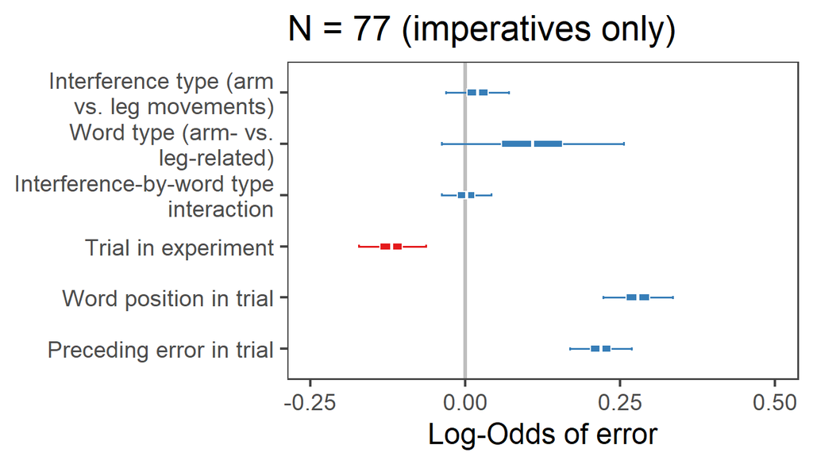

```r
plot_mymodel(results_brms_d77_imperat[[1]], "N = 77 (imperatives only)")
```

```
## Note: uncertainty of error terms are not taken into account. You may want to use `rstantools::posterior_predict()`.
```

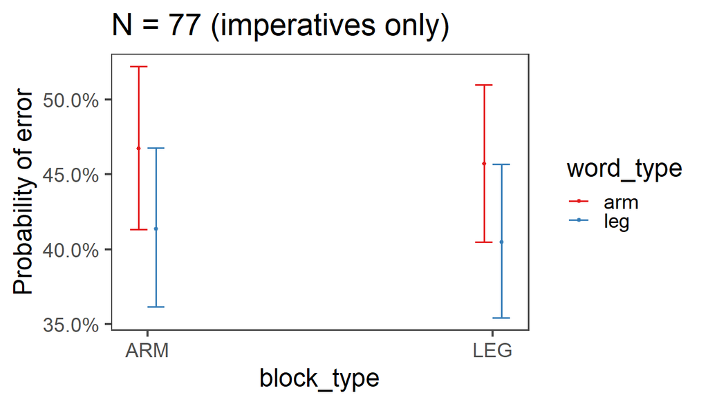

```r
my_ggsave("SP13_replication_model_estim_d77_imperat", 6, 6)
plot_interaction(results_brms_d77_imperat[[1]], "N = 77 (imperatives only)")
```

```r
my_ggsave("SP13_replication_model_interact_d77_imperat", 6, 6)
```

#### 4.4.2.2 Bayes factor

Compute Bayes Factor:

```r
ptm <- proc.time()
results_brms_d77_imperat_BF <- my_BF_wrapper(results_brms_d77_imperat)
```

```
## [1] "mymodels/results_brms_d77_imperat_BF.rds"
## The BF analysis mymodels/results_brms_d77_imperat_BF.rds exists on disk, so we load it...
```

```r
time_bridge <- proc.time() - ptm
time_bridge
```

```
##    user  system elapsed
##       0       0       0
```

**Bayes factor:**

```r
results_brms_d77_imperat_BF
```

```
## Estimated Bayes factor in favor of bridge1 over bridge2: 0.01088
```

```r
1 / results_brms_d77_imperat_BF$bf
```

```
## [1] 91.89461
```

```r
# memory management
rm(results_brms_d77_imperat, results_brms_d77_imperat_BF)
```

### 4.4.3 Secondary analysis - replication BF using original results from SP13 as priors

#### 4.4.3.1 Model fitting

Fit the models:

```r
ptm <- proc.time()
results_brms_d77_imperat_repBF <- analysis_pipe(d77_imperat, repBF = TRUE,
                                                repBF_post = sp13_posterior)
```

```
## The list of models mymodels/results_brms_d77_imperat_repBF.rds exists on disk, so we load it...
```

```r
# Stop the clock
time_models <- proc.time() - ptm
time_models
```

```
##    user  system elapsed
##   20.21    1.39   22.00
```

#### 4.4.3.2 Replication Bayes factor

Compute Replication Bayes factor:

```r
ptm <- proc.time()
results_brms_d77_imperat_repBF_BF <- my_BF_wrapper(results_brms_d77_imperat_repBF)
```

```
## [1] "mymodels/results_brms_d77_imperat_repBF_BF.rds"
## The BF analysis mymodels/results_brms_d77_imperat_repBF_BF.rds exists on disk, so we load it...
```

```r
time_bridge <- proc.time() - ptm
time_bridge
```

```
##    user  system elapsed
##    0.00    0.00    0.01
```

**Bayes factor:**

```r
results_brms_d77_imperat_repBF_BF
```

```
## Estimated Bayes factor in favor of bridge1 over bridge2: 0.00811
```

```r
1 / results_brms_d77_imperat_repBF_BF$bf
```

```
## [1] 123.3328
```

```r
# memory management
rm(results_brms_d77_imperat_repBF, results_brms_d77_imperat_repBF_BF)
```

# 5 Results with $N=60$

In the article, we report the analyses with all 77 participants, as these should provide the most robust estimates of the effects. However, none of our conclusions hinges on this choice. Below, we run identical analyses with our first 60 participants. None of the crucial results change; there are only minor differences in the model estimates for our predictors and generally slightly larger 95% credible intervals, as might be expected from the somewhat reduced sample size.

## 5.1 Visualization of raw data

Critical conditions:

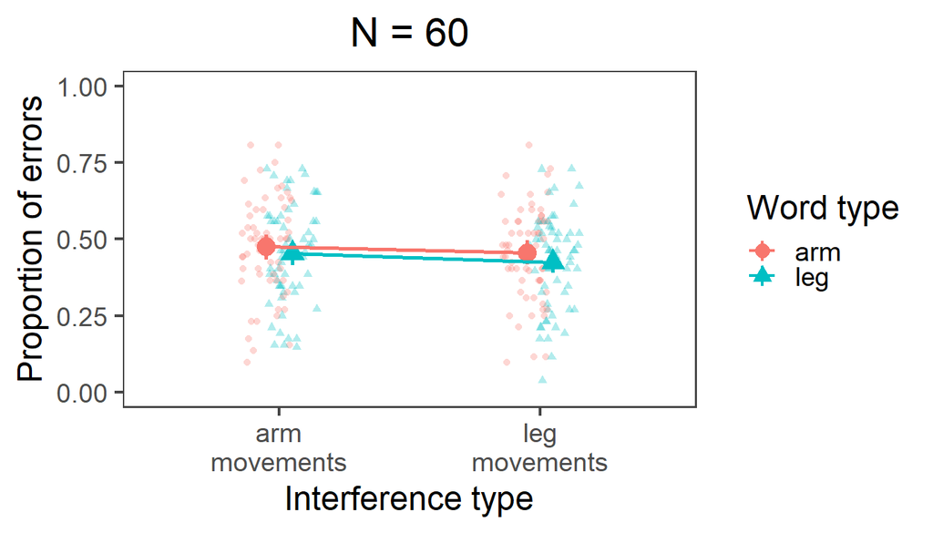

```r
plot_raw_data(d60_w_control, "N = 60")
```

```r
my_ggsave("SP13_replication_raw_d60", 6, 4)
```

Including the control condition for comparison:

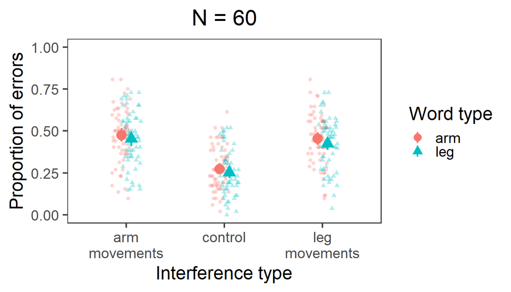

```r
plot_raw_data(d60_w_control, "N = 60", excl_CONTROL = FALSE)
```

```r
my_ggsave("SP13_replication_raw_control_d60", 6, 4)
```

## 5.2 Analysis with pre-registered analysis pipeline

### 5.2.1 Main analysis - with weakly informative priors

#### 5.2.1.1 Model fitting

Fit the models (or load if already fitted):

```r
ptm <- proc.time()
# analysis_pipe() tries to load the models from disk and fits them if that fails
results_brms_d60 <- analysis_pipe(d60)
```

```
## The list of models mymodels/results_brms_d60.rds exists on disk, so we load it...
```

```r
# Stop the clock
time_models <- proc.time() - ptm
time_models
```

```
##    user  system elapsed
##   18.75    1.16   21.92
```

#### 5.2.1.2 Model visualization

Visualization of the model estimates:

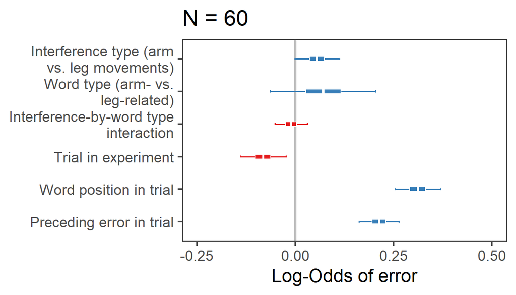

```r
plot_mymodel(results_brms_d60[[1]], "N = 60")
```

```
## Note: uncertainty of error terms are not taken into account. You may want to use `rstantools::posterior_predict()`.
```

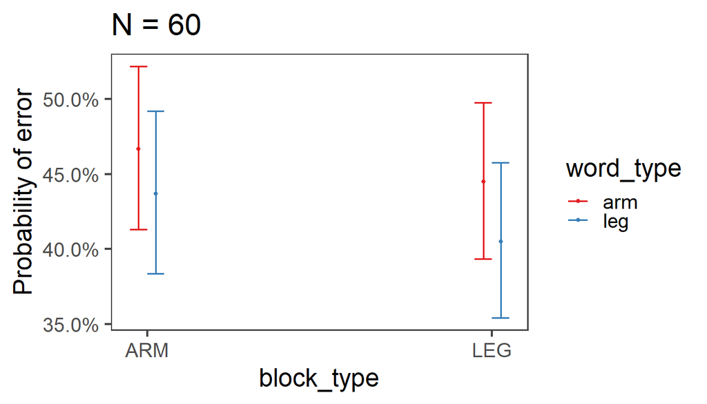

```r
my_ggsave("SP13_replication_model_estim_d60", 6, 6)
plot_interaction(results_brms_d60[[1]], "N = 60")
```

```r
my_ggsave("SP13_replication_model_interact_d60", 6, 6)
```

#### 5.2.1.3 Model summaries

Model summaries for each of the two models, the full and the null version:

```r
summary(results_brms_d60[[1]])  # full
```

```
##  Family: bernoulli
##   Links: mu = logit
## Formula: error ~ block_type + word_type + trial_exp_z + word_pos_z + preced_error_z + (1 + block_type * word_type | subject) + (1 + block_type | verb) + block_type:word_type
##    Data: df (Number of observations: 12312)
## Samples: 4 chains, each with iter = 20000; warmup = 2000; thin = 1;
##          total post-warmup samples = 72000
##
## Group-Level Effects:
## ~subject (Number of levels: 60)
##                                                                    Estimate
## sd(Intercept)                                                          0.69
## sd(block_typearm_vs_leg)                                               0.15
## sd(word_typearm_vs_leg)                                                0.06
## sd(block_typearm_vs_leg:word_typearm_vs_leg)                           0.02
## cor(Intercept,block_typearm_vs_leg)                                    0.10
## cor(Intercept,word_typearm_vs_leg)                                    -0.06
## cor(block_typearm_vs_leg,word_typearm_vs_leg)                          0.12
## cor(Intercept,block_typearm_vs_leg:word_typearm_vs_leg)                0.02
## cor(block_typearm_vs_leg,block_typearm_vs_leg:word_typearm_vs_leg)    -0.02
## cor(word_typearm_vs_leg,block_typearm_vs_leg:word_typearm_vs_leg)      0.04
##                                                                    Est.Error
## sd(Intercept)                                                           0.07
## sd(block_typearm_vs_leg)                                                0.03
## sd(word_typearm_vs_leg)                                                 0.04
## sd(block_typearm_vs_leg:word_typearm_vs_leg)                            0.02
## cor(Intercept,block_typearm_vs_leg)                                     0.20
## cor(Intercept,word_typearm_vs_leg)                                      0.34
## cor(block_typearm_vs_leg,word_typearm_vs_leg)                           0.38
## cor(Intercept,block_typearm_vs_leg:word_typearm_vs_leg)                 0.44
## cor(block_typearm_vs_leg,block_typearm_vs_leg:word_typearm_vs_leg)      0.44
## cor(word_typearm_vs_leg,block_typearm_vs_leg:word_typearm_vs_leg)       0.45
##                                                                    l-95% CI
## sd(Intercept)                                                          0.57
## sd(block_typearm_vs_leg)                                               0.09
## sd(word_typearm_vs_leg)                                                0.00
## sd(block_typearm_vs_leg:word_typearm_vs_leg)                           0.00
## cor(Intercept,block_typearm_vs_leg)                                   -0.29
## cor(Intercept,word_typearm_vs_leg)                                    -0.71
## cor(block_typearm_vs_leg,word_typearm_vs_leg)                         -0.66
## cor(Intercept,block_typearm_vs_leg:word_typearm_vs_leg)               -0.79
```

[output cut: 63 more lines]

```
## word_pos_z                                   0.31      0.03     0.25
## preced_error_z                               0.21      0.03     0.16
## block_typearm_vs_leg:word_typearm_vs_leg    -0.01      0.02    -0.05
##                                          u-95% CI Rhat Bulk_ESS Tail_ESS
## Intercept                                   -0.03 1.00     9954    19771
## block_typearm_vs_leg                         0.11 1.00    66123    58655
## word_typearm_vs_leg                          0.20 1.00    13532    26440
## trial_exp_z                                 -0.02 1.00    63892    55731
## word_pos_z                                   0.37 1.00    84599    58088
## preced_error_z                               0.26 1.00    98840    60702
## block_typearm_vs_leg:word_typearm_vs_leg     0.03 1.00   139536    53046
##
## Samples were drawn using sampling(NUTS). For each parameter, Eff.Sample
## is a crude measure of effective sample size, and Rhat is the potential
## scale reduction factor on split chains (at convergence, Rhat = 1).
```

```r
summary(results_brms_d60[[2]])  # null
```

```
##  Family: bernoulli
##   Links: mu = logit
## Formula: error ~ block_type + word_type + trial_exp_z + word_pos_z + preced_error_z + (1 + block_type * word_type | subject) + (1 + block_type | verb)
##    Data: df (Number of observations: 12312)
## Samples: 4 chains, each with iter = 20000; warmup = 2000; thin = 1;
##          total post-warmup samples = 72000
##
## Group-Level Effects:
## ~subject (Number of levels: 60)
##                                                                    Estimate
## sd(Intercept)                                                          0.69
## sd(block_typearm_vs_leg)                                               0.15
## sd(word_typearm_vs_leg)                                                0.06
## sd(block_typearm_vs_leg:word_typearm_vs_leg)                           0.02
## cor(Intercept,block_typearm_vs_leg)                                    0.11
## cor(Intercept,word_typearm_vs_leg)                                    -0.06
## cor(block_typearm_vs_leg,word_typearm_vs_leg)                          0.11
## cor(Intercept,block_typearm_vs_leg:word_typearm_vs_leg)                0.02
## cor(block_typearm_vs_leg,block_typearm_vs_leg:word_typearm_vs_leg)    -0.02
## cor(word_typearm_vs_leg,block_typearm_vs_leg:word_typearm_vs_leg)      0.05
##                                                                    Est.Error
## sd(Intercept)                                                           0.07
## sd(block_typearm_vs_leg)                                                0.03
## sd(word_typearm_vs_leg)                                                 0.04
## sd(block_typearm_vs_leg:word_typearm_vs_leg)                            0.02
## cor(Intercept,block_typearm_vs_leg)                                     0.20
## cor(Intercept,word_typearm_vs_leg)                                      0.34
## cor(block_typearm_vs_leg,word_typearm_vs_leg)                           0.38
## cor(Intercept,block_typearm_vs_leg:word_typearm_vs_leg)                 0.43
## cor(block_typearm_vs_leg,block_typearm_vs_leg:word_typearm_vs_leg)      0.44
## cor(word_typearm_vs_leg,block_typearm_vs_leg:word_typearm_vs_leg)       0.45
##                                                                    l-95% CI
## sd(Intercept)                                                          0.56
## sd(block_typearm_vs_leg)                                               0.09
## sd(word_typearm_vs_leg)                                                0.00
## sd(block_typearm_vs_leg:word_typearm_vs_leg)                           0.00
## cor(Intercept,block_typearm_vs_leg)                                   -0.29
## cor(Intercept,word_typearm_vs_leg)                                    -0.71
## cor(block_typearm_vs_leg,word_typearm_vs_leg)                         -0.66
## cor(Intercept,block_typearm_vs_leg:word_typearm_vs_leg)               -0.79
```

[output cut: 61 more lines]

```
## word_typearm_vs_leg      0.07      0.07    -0.06     0.21 1.00    16075
## trial_exp_z             -0.08      0.03    -0.14    -0.02 1.00    74686
## word_pos_z               0.31      0.03     0.25     0.37 1.00   103107
## preced_error_z           0.21      0.03     0.16     0.26 1.00   112396
##                      Tail_ESS
## Intercept               23236
## block_typearm_vs_leg    60518
## word_typearm_vs_leg     29840
## trial_exp_z             57049
## word_pos_z              57277
## preced_error_z          58200
##
## Samples were drawn using sampling(NUTS). For each parameter, Eff.Sample
## is a crude measure of effective sample size, and Rhat is the potential
## scale reduction factor on split chains (at convergence, Rhat = 1).
```

#### 5.2.1.4 Bayes factor

Compute Bayes Factor:

```r
ptm <- proc.time()
results_brms_d60_BF <- my_BF_wrapper(results_brms_d60)
```

```
## [1] "mymodels/results_brms_d60_BF.rds"
## The BF analysis mymodels/results_brms_d60_BF.rds exists on disk, so we load it...
```

```r
time_bridge <- proc.time() - ptm
time_bridge
```

```
##    user  system elapsed
##    0.00    0.00    0.01
```

**Bayes factor:**

```r
results_brms_d60_BF
```

```
## Estimated Bayes factor in favor of bridge1 over bridge2: 0.01187
```

```r
1 / results_brms_d60_BF$bf
```

```
## [1] 84.26539
```

```r
# memory management
rm(results_brms_d60, results_brms_d60_BF)
```

### 5.2.2 Secondary analysis - replication BF using original results from SP13 as priors

#### 5.2.2.1 Model fitting

Fit the models:

```r
ptm <- proc.time()
results_brms_d60_repBF <- analysis_pipe(d60, repBF = TRUE, repBF_post = sp13_posterior)
```

```
## The list of models mymodels/results_brms_d60_repBF.rds exists on disk, so we load it...
```

```r
# Stop the clock
time_models <- proc.time() - ptm
time_models
```

```
##    user  system elapsed
##   18.80    1.45   21.02
```

#### 5.2.2.2 Model summaries

Model summaries:

```r
summary(results_brms_d60_repBF[[1]])  # full
```

```
##  Family: bernoulli
##   Links: mu = logit
## Formula: error ~ block_type + word_type + trial_exp_z + word_pos_z + preced_error_z + (1 + block_type * word_type | subject) + (1 + block_type | verb) + block_type:word_type
##    Data: df (Number of observations: 12312)
## Samples: 4 chains, each with iter = 20000; warmup = 2000; thin = 1;
##          total post-warmup samples = 72000
##
## Group-Level Effects:
## ~subject (Number of levels: 60)
##                                                                    Estimate
## sd(Intercept)                                                          0.69
## sd(block_typearm_vs_leg)                                               0.15
## sd(word_typearm_vs_leg)                                                0.06
## sd(block_typearm_vs_leg:word_typearm_vs_leg)                           0.02
## cor(Intercept,block_typearm_vs_leg)                                    0.11
## cor(Intercept,word_typearm_vs_leg)                                    -0.06
## cor(block_typearm_vs_leg,word_typearm_vs_leg)                          0.11
## cor(Intercept,block_typearm_vs_leg:word_typearm_vs_leg)                0.00
## cor(block_typearm_vs_leg,block_typearm_vs_leg:word_typearm_vs_leg)    -0.02
## cor(word_typearm_vs_leg,block_typearm_vs_leg:word_typearm_vs_leg)      0.05
##                                                                    Est.Error
## sd(Intercept)                                                           0.07
## sd(block_typearm_vs_leg)                                                0.03
## sd(word_typearm_vs_leg)                                                 0.04
## sd(block_typearm_vs_leg:word_typearm_vs_leg)                            0.02
## cor(Intercept,block_typearm_vs_leg)                                     0.20
## cor(Intercept,word_typearm_vs_leg)                                      0.34
## cor(block_typearm_vs_leg,word_typearm_vs_leg)                           0.38
## cor(Intercept,block_typearm_vs_leg:word_typearm_vs_leg)                 0.43
## cor(block_typearm_vs_leg,block_typearm_vs_leg:word_typearm_vs_leg)      0.44
## cor(word_typearm_vs_leg,block_typearm_vs_leg:word_typearm_vs_leg)       0.45
##                                                                    l-95% CI
## sd(Intercept)                                                          0.57
## sd(block_typearm_vs_leg)                                               0.09
## sd(word_typearm_vs_leg)                                                0.00
## sd(block_typearm_vs_leg:word_typearm_vs_leg)                           0.00
## cor(Intercept,block_typearm_vs_leg)                                   -0.28
## cor(Intercept,word_typearm_vs_leg)                                    -0.71
## cor(block_typearm_vs_leg,word_typearm_vs_leg)                         -0.66
## cor(Intercept,block_typearm_vs_leg:word_typearm_vs_leg)               -0.80
```

[output cut: 63 more lines]

```
## word_pos_z                                   0.31      0.03     0.25
## preced_error_z                               0.21      0.03     0.16
## block_typearm_vs_leg:word_typearm_vs_leg     0.01      0.02    -0.02
##                                          u-95% CI Rhat Bulk_ESS Tail_ESS
## Intercept                                   -0.03 1.00    10789    21399
## block_typearm_vs_leg                         0.11 1.00    73929    60459
## word_typearm_vs_leg                          0.21 1.00    16471    30458
## trial_exp_z                                 -0.02 1.00    74592    60804
## word_pos_z                                   0.37 1.00   100261    60251
## preced_error_z                               0.26 1.00   110455    58713
## block_typearm_vs_leg:word_typearm_vs_leg     0.05 1.00   157457    54285
##
## Samples were drawn using sampling(NUTS). For each parameter, Eff.Sample
## is a crude measure of effective sample size, and Rhat is the potential
## scale reduction factor on split chains (at convergence, Rhat = 1).
```

```r
summary(results_brms_d60_repBF[[2]])  # null
```

```
##  Family: bernoulli
##   Links: mu = logit
## Formula: error ~ block_type + word_type + trial_exp_z + word_pos_z + preced_error_z + (1 + block_type * word_type | subject) + (1 + block_type | verb)
##    Data: df (Number of observations: 12312)
## Samples: 4 chains, each with iter = 20000; warmup = 2000; thin = 1;
##          total post-warmup samples = 72000
##
## Group-Level Effects:
## ~subject (Number of levels: 60)
##                                                                    Estimate
## sd(Intercept)                                                          0.69
## sd(block_typearm_vs_leg)                                               0.15
## sd(word_typearm_vs_leg)                                                0.06
## sd(block_typearm_vs_leg:word_typearm_vs_leg)                           0.02
## cor(Intercept,block_typearm_vs_leg)                                    0.11
## cor(Intercept,word_typearm_vs_leg)                                    -0.06
## cor(block_typearm_vs_leg,word_typearm_vs_leg)                          0.11
## cor(Intercept,block_typearm_vs_leg:word_typearm_vs_leg)                0.01
## cor(block_typearm_vs_leg,block_typearm_vs_leg:word_typearm_vs_leg)    -0.02
## cor(word_typearm_vs_leg,block_typearm_vs_leg:word_typearm_vs_leg)      0.04
##                                                                    Est.Error
## sd(Intercept)                                                           0.07
## sd(block_typearm_vs_leg)                                                0.03
## sd(word_typearm_vs_leg)                                                 0.04
## sd(block_typearm_vs_leg:word_typearm_vs_leg)                            0.02
## cor(Intercept,block_typearm_vs_leg)                                     0.20
## cor(Intercept,word_typearm_vs_leg)                                      0.34
## cor(block_typearm_vs_leg,word_typearm_vs_leg)                           0.38
## cor(Intercept,block_typearm_vs_leg:word_typearm_vs_leg)                 0.43
## cor(block_typearm_vs_leg,block_typearm_vs_leg:word_typearm_vs_leg)      0.44
## cor(word_typearm_vs_leg,block_typearm_vs_leg:word_typearm_vs_leg)       0.45
##                                                                    l-95% CI
## sd(Intercept)                                                          0.57
## sd(block_typearm_vs_leg)                                               0.09
## sd(word_typearm_vs_leg)                                                0.00
## sd(block_typearm_vs_leg:word_typearm_vs_leg)                           0.00
## cor(Intercept,block_typearm_vs_leg)                                   -0.28
## cor(Intercept,word_typearm_vs_leg)                                    -0.71
## cor(block_typearm_vs_leg,word_typearm_vs_leg)                         -0.66
## cor(Intercept,block_typearm_vs_leg:word_typearm_vs_leg)               -0.79
```

[output cut: 61 more lines]

```
## word_typearm_vs_leg      0.07      0.07    -0.06     0.21 1.00    13117
## trial_exp_z             -0.08      0.03    -0.14    -0.02 1.00    59582
## word_pos_z               0.31      0.03     0.25     0.37 1.00    76847
## preced_error_z           0.21      0.03     0.16     0.26 1.00    89263
##                      Tail_ESS
## Intercept               17850
## block_typearm_vs_leg    57327
## word_typearm_vs_leg     25916
## trial_exp_z             56421
## word_pos_z              58331
## preced_error_z          56841
##
## Samples were drawn using sampling(NUTS). For each parameter, Eff.Sample
## is a crude measure of effective sample size, and Rhat is the potential
## scale reduction factor on split chains (at convergence, Rhat = 1).
```

#### 5.2.2.3 Replication Bayes factor

Compute Replication Bayes factor:

```r
ptm <- proc.time()
results_brms_d60_repBF_BF <- my_BF_wrapper(results_brms_d60_repBF)
```

```
## [1] "mymodels/results_brms_d60_repBF_BF.rds"
## The BF analysis mymodels/results_brms_d60_repBF_BF.rds exists on disk, so we load it...
```

```r
time_bridge <- proc.time() - ptm
time_bridge
```

```
##    user  system elapsed
##    0.00    0.00    0.02
```

**Bayes factor:**

```r
results_brms_d60_repBF_BF
```

```
## Estimated Bayes factor in favor of bridge1 over bridge2: 0.00555
```

```r
1 / results_brms_d60_repBF_BF$bf
```

```
## [1] 180.0846
```